This is my analysis of the Titanic dataset as supplied by Kaggle.com for their 'Titanic: Machine Learning from Disaster' competition. My goal was to score above 0.8, and I am pleased to say that I have accomplished this, as I have reached the score of 0.80861, which puts me in the top 9% of entries.

The sections for this analysis are: data exploration, feature engineering, machine learning, and evaluation.

```python
import numpy as np
import pandas as pd
from sklearn import cross_validation
from sklearn.linear_model import LogisticRegression
import operator
import re
from sklearn.feature_selection import SelectKBest, f_classif
import matplotlib.pyplot as plt
from sklearn.ensemble import RandomForestClassifier
from sklearn.ensemble import ExtraTreesClassifier
from sklearn.pipeline import Pipeline
from sklearn.cross_validation import KFold
from sklearn.decomposition import PCA
from sklearn.grid_search import GridSearchCV
from sklearn.cross_validation import train_test_split
from sklearn.pipeline import FeatureUnion
from sklearn.ensemble import GradientBoostingClassifier
from scipy.stats.stats import pearsonr
from sklearn.tree import DecisionTreeClassifier
from sklearn.ensemble import AdaBoostClassifier
from sklearn.metrics import accuracy_score
from sklearn.ensemble import VotingClassifier
from sklearn.naive_bayes import GaussianNB
from sklearn import neighbors
from nameparser import HumanName
```

# Section 1: Data Exploration

Step one, load the data.

```python
train = pd.read_csv("/Users/Dave/Desktop/Programming/Personal Projects/titanic_kaggle/train.csv")
test = pd.read_csv("/Users/Dave/Desktop/Programming/Personal Projects/titanic_kaggle/test.csv")
```

Let's see what kind of data we are working with

```python
train.describe()
```

|  | PassengerId | Survived | Pclass | Age | SibSp | Parch | Fare |
| --- | --- | --- | --- | --- | --- | --- | --- |
| count | 891.000000 | 891.000000 | 891.000000 | 714.000000 | 891.000000 | 891.000000 | 891.000000 |
| mean | 446.000000 | 0.383838 | 2.308642 | 29.699118 | 0.523008 | 0.381594 | 32.204208 |
| std | 257.353842 | 0.486592 | 0.836071 | 14.526497 | 1.102743 | 0.806057 | 49.693429 |
| min | 1.000000 | 0.000000 | 1.000000 | 0.420000 | 0.000000 | 0.000000 | 0.000000 |
| 25% | 223.500000 | 0.000000 | 2.000000 | NaN | 0.000000 | 0.000000 | 7.910400 |
| 50% | 446.000000 | 0.000000 | 3.000000 | NaN | 0.000000 | 0.000000 | 14.454200 |
| 75% | 668.500000 | 1.000000 | 3.000000 | NaN | 1.000000 | 0.000000 | 31.000000 |
| max | 891.000000 | 1.000000 | 3.000000 | 80.000000 | 8.000000 | 6.000000 | 512.329200 |

```python
train.head()
```

|  | PassengerId | Survived | Pclass | Name | Sex | Age | SibSp | Parch | Ticket | Fare | Cabin | Embarked |
| --- | --- | --- | --- | --- | --- | --- | --- | --- | --- | --- | --- | --- |
| 0 | 1 | 0 | 3 | Braund, Mr. Owen Harris | male | 22.0 | 1 | 0 | A/5 21171 | 7.2500 | NaN | S |
| 1 | 2 | 1 | 1 | Cumings, Mrs. John Bradley (Florence Briggs Th... | female | 38.0 | 1 | 0 | PC 17599 | 71.2833 | C85 | C |
| 2 | 3 | 1 | 3 | Heikkinen, Miss. Laina | female | 26.0 | 0 | 0 | STON/O2. 3101282 | 7.9250 | NaN | S |
| 3 | 4 | 1 | 1 | Futrelle, Mrs. Jacques Heath (Lily May Peel) | female | 35.0 | 1 | 0 | 113803 | 53.1000 | C123 | S |
| 4 | 5 | 0 | 3 | Allen, Mr. William Henry | male | 35.0 | 0 | 0 | 373450 | 8.0500 | NaN | S |

We can already see that we have some missing data in the Cabin variable. Let's have a look at what else we are missing.

```python
train.isnull().sum()
```

```
PassengerId      0
Survived         0
Pclass           0
Name             0
Sex              0
Age            177
SibSp            0
Parch            0
Ticket           0
Fare             0
Cabin          687
Embarked         2
dtype: int64
```

Pretty good for the most part. Age is missing about 20% of its data, hopefully we will be able to use other data to provide a fair guess as to what those ages should be. Cabin is missing most of its data, but we might be able to learn something from the information that we have. Embarked is missing just two values, that won't be a problem.

Next, let's look at the data via some graphs.

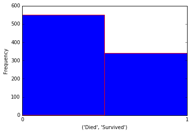

```
0    549
1    342
Name: Survived, dtype: int64
```

```python
train.Survived.plot(kind='hist', bins = 2, edgecolor = 'red')
plt.xticks((1, 0))
plt.xlabel(('Died','Survived'))
plt.show()
train.Survived.value_counts()
```

61.6% of people died...

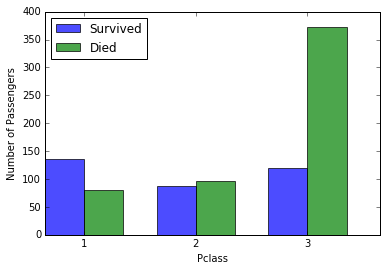

```
Survived    0    1  All
Pclass
1          80  136  216
2          97   87  184
3         372  119  491
All       549  342  891
```

```python
n_groups = 3
index = np.arange(n_groups)
bar_width = 0.35
opacity = 0.7

PclassSurvived = train[train.Survived==1].Pclass.value_counts().sort_index()
PclassDied = train[train.Survived==0].Pclass.value_counts().sort_index()

plt.bar(index, PclassSurvived, bar_width,
        alpha=opacity,
        color='b',
        label='Survived')

plt.bar(index + bar_width, PclassDied, bar_width,
        alpha=opacity,
        color='g',
        label='Died')

plt.xticks(index + bar_width, (1,2,3))
plt.xlabel("Pclass")
plt.ylabel("Number of Passengers")
plt.legend(loc = 2)
plt.show()

print pd.crosstab(train.Pclass, train.Survived, margins=True)
```

Looks like you don't want to be in third class. I wonder what happens when we factor in gender as well.

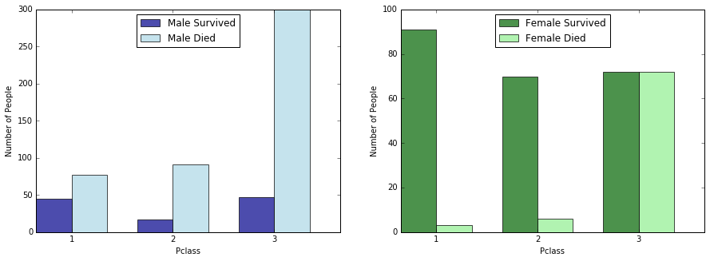

```
Male Values:
Survived    0    1  All
Pclass
1          77   45  122
2          91   17  108
3         300   47  347
All       468  109  577

Female Values:
Survived   0    1  All
Pclass
1          3   91   94
2          6   70   76
3         72   72  144
All       81  233  314
```

```python
n_groups = 3
index = np.arange(n_groups)
bar_width = 0.35
opacity = 0.7

trainMale = train[train.Sex == 'male']
trainFemale = train[train.Sex == 'female']

PclassMaleSurvived = trainMale[trainMale.Survived==1].Pclass.value_counts().sort_index()
PclassMaleDied = trainMale[trainMale.Survived==0].Pclass.value_counts().sort_index()

PclassFemaleSurvived = trainFemale[trainFemale.Survived==1].Pclass.value_counts().sort_index()
PclassFemaleDied = trainFemale[trainFemale.Survived==0].Pclass.value_counts().sort_index()

fig, axes = plt.subplots(nrows=1, ncols=2, figsize=(15, 5))


PclassM1 = axes[0].bar(index, PclassMaleSurvived, bar_width,
                 alpha=opacity,
                 color='darkblue',
                 label='Male Survived')

PclassM0 = axes[0].bar(index + bar_width, PclassMaleDied, bar_width,
                 alpha=opacity,
                 color='lightblue',
                 label='Male Died')

PclassF1 = axes[1].bar(index, PclassFemaleSurvived, bar_width,
                 alpha=opacity,
                 color='darkgreen',
                 label='Female Survived')

PclassF0 = axes[1].bar(index + bar_width, PclassFemaleDied, bar_width,
                 alpha=opacity,
                 color='lightgreen',
                 label='Female Died')

for ax in axes:
    ax.legend(loc = 9)
    ax.set_xlabel('Pclass')
    ax.set_ylabel('Number of People')

plt.setp(axes,
         xticks = index + bar_width,
         xticklabels=['1', '2', '3'],
        )
plt.show()

print "Male Values:"
print pd.crosstab(trainMale.Pclass, trainMale.Survived, margins = True)
print ""
print "Female Values:"
print pd.crosstab(trainFemale.Pclass, trainFemale.Survived, margins = True)
```

Upper and middle class women mostly survived, not so much for the lower class. None of the men did particularly well, especially those in the lower class.

To get a better general sense, let's compare the survival of men and women.

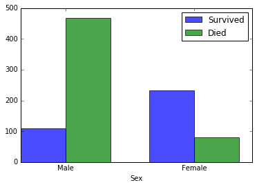

```
Total number of people in each sex:
Survived    0    1  All
Sex
female     81  233  314
male      468  109  577
All       549  342  891
```

```python
n_groups = 2
index = np.arange(n_groups)
bar_width = 0.35
opacity = 0.7

SexSurvived = train[train.Survived==1].Sex.value_counts().sort_index(ascending = False)
SexDied = train[train.Survived==0].Sex.value_counts().sort_index(ascending = False)

Sex1 = plt.bar(index, SexSurvived, bar_width,
                 alpha=opacity,
                 color='b',
                 label='Survived')
Sex0 = plt.bar(index + bar_width, SexDied, bar_width,
                 alpha=opacity,
                 color='g',
                 label='Died')
plt.xticks(index + bar_width, ('Male', 'Female'))
plt.xlabel("Sex")
plt.legend()
plt.show()

print "Total number of people in each sex:"
print pd.crosstab(train.Sex, train.Survived, margins = True)
```

As expected, women typically survived and men did not.

Let's move on to Ages, and see how things worked out there.

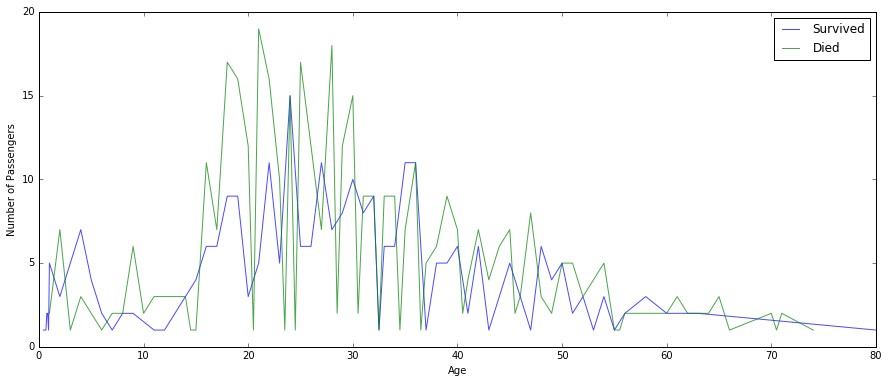

```python
fig = plt.figure(figsize=(15, 6))
alpha = 0.7

AgeSurvived = train[train.Survived==1].Age.value_counts().sort_index()
AgeDied = train[train.Survived==0].Age.value_counts().sort_index()

Age1 = plt.plot(AgeSurvived,
                 alpha=opacity,
                 color='b',
                 label='Survived')
Age0 = plt.plot(AgeDied,
                 alpha=opacity,
                 color='g',
                 label='Died')
plt.xlabel("Age")
plt.ylabel("Number of Passengers")
plt.legend()
plt.show()
```

It appears that passengers near the age of 4/5 are more likely to survive, otherwise it seems that death is more common.

```python
print "Now let's take care of those", train.Age.isnull().sum(), "null values"
```

```
Now let's take care of those 177 null values
```

```python
print "One idea would be to take the median age:", train.Age.median(), "or mean:", train.Age.mean(), "but I think we can get a clue from people's titles (ex Mr., Mrs.)"
```

```
One idea would be to take the median age: 28.0 or mean: 29.6991176471 but I think we can get a clue from people's titles (ex Mr., Mrs.)
```

First let's see what titles we have.

```python
titles = []
for name in train.Name:
    titles.append(HumanName(name).title)
print set(titles)
```

```
set([u'', u'Miss.', u'Rev.', u'Sir.', u'Mrs.', u'Capt.', u'Col.', u'Ms.', u'Mr.', u'Lady.', u'Dr.', u'Master.'])
```

The titles look good, expect there's an empty string, perhaps that's for the less common titles, but I feel pretty good about this range since it has covered the basicis. Now let's make a new feature for these titles.

```python
train.Title = train.Name.map(lambda x: HumanName(x).title)
```

```python
print train[train.Title == ''].Name
print train[train.Title == ''].Survived
```

```
30                              Uruchurtu, Don. Manuel E
369                        Aubart, Mme. Leontine Pauline
449                       Peuchen, Major. Arthur Godfrey
536                    Butt, Major. Archibald Willingham
641                                 Sagesser, Mlle. Emma
710     Mayne, Mlle. Berthe Antonine ("Mrs de Villiers")
759    Rothes, the Countess. of (Lucy Noel Martha Dye...
822                      Reuchlin, Jonkheer. John George
Name: Name, dtype: object
30     0
369    1
449    1
536    0
641    1
710    1
759    1
822    0
Name: Survived, dtype: int64
```

```python
titleAges = {}
for title in train.Title:
    if title not in titleAges:
        titleAges[title] = train[train.Title == title].Age.median()
print titleAges
```

```
{u'': 35.5, u'Miss.': 21.0, u'Rev.': 46.5, u'Sir.': 49.0, u'Mrs.': 35.0, u'Capt.': 70.0, u'Col.': 58.0, u'Ms.': 28.0, u'Mr.': 30.0, u'Lady.': 48.0, u'Dr.': 46.5, u'Master.': 3.5}
```

Now we can add the median age of the respective title to the passengers who do not have an age.

```python
for title in train.Title:
    train.Age = train.Age.fillna(titleAges[title])
```

Now let's do the same for the test dataframe, to keep things equal.

```python
test.Title = test.Name.map(lambda x: HumanName(x).title)
testTitleAges = {}
for title in test.Title:
    if title not in testTitleAges:
        testTitleAges[title] = test[test.Title == title].Age.median()
for title in test.Title:
    test.Age = test.Age.fillna(testTitleAges[title])
```

Next, let's move on to SibSp (siblings and spouses)

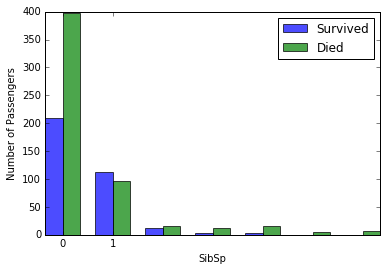

```
Number of people in each SibSp group:
```

| Survived SibSp | 0 | 1 | All |
| --- | --- | --- | --- |
| 0 | 398 | 210 | 608 |
| 1 | 97 | 112 | 209 |
| 2 | 15 | 13 | 28 |
| 3 | 12 | 4 | 16 |
| 4 | 15 | 3 | 18 |
| 5 | 5 | 0 | 5 |
| 8 | 7 | 0 | 7 |
| All | 549 | 342 | 891 |

```python
n_groups1 = 5
index1 = np.arange(n_groups1)
n_groups2 = 7
index2 = np.arange(n_groups2)
bar_width = 0.35
opacity = 0.7

SSSurvived = train[train.Survived==1].SibSp.value_counts().sort_index()
SSDied = train[train.Survived==0].SibSp.value_counts().sort_index()

SS1 = plt.bar(index1, SSSurvived, bar_width,
                 alpha=opacity,
                 color='b',
                 label='Survived')
plt.xticks(index + bar_width, (0,1,2,3,4,5,8))

SS0 = plt.bar(index2 + bar_width, SSDied, bar_width,
                 alpha=opacity,
                 color='g',
                 label='Died')

plt.xlabel("SibSp")
plt.ylabel("Number of Passengers")
plt.legend()
plt.show()
print "Number of people in each SibSp group:"
pd.crosstab(train.SibSp, train.Survived, margins = True)
```

Things only look decent for pairs, otherwise not too brilliant.

Next, to Parch (parents and children).

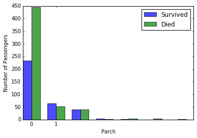

```
Number of people in each Parch group:
Survived    0    1  All
Parch
0         445  233  678
1          53   65  118
2          40   40   80
3           2    3    5
4           4    0    4
5           4    1    5
6           1    0    1
All       549  342  891
```

```python
n_groups1 = 5
index1 = np.arange(n_groups1)
n_groups2 = 7
index2 = np.arange(n_groups2)
bar_width = 0.35
opacity = 0.7

PCSurvived = train[train.Survived==1].Parch.value_counts().sort_index()
PCDied = train[train.Survived==0].Parch.value_counts().sort_index()

PC1 = plt.bar(index1, PCSurvived, bar_width,
                 alpha=opacity,
                 color='b',
                 label='Survived')

PC0 = plt.bar(index2 + bar_width, PCDied, bar_width,
                 alpha=opacity,
                 color='g',
                 label='Died')

plt.xlabel("Parch")
plt.legend()
plt.xticks(index + bar_width, (0,1,2,3,4,5,6))
plt.ylabel("Number of Passengers")
plt.show()
print "Number of people in each Parch group:"
print pd.crosstab(train.Parch, train.Survived, margins = True)
```

Hmm, this looks very similar to the SibSp plot/values. I'm going to combine the two, and call the new variable 'FamilyMembers.' Perhaps something will standout here. I'm particularly interested in passengers with 2 family members, as they might be the most likely to survived based on the SibSp and Parch data.

```python
train['FamilyMembers'] = (train.SibSp + train.Parch)
test['FamilyMembers'] = (test.SibSp + test.Parch)
```

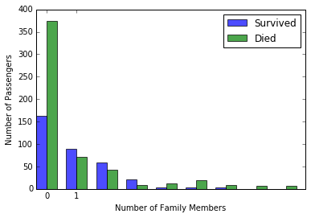

```
Number of people in each Family Member size:
Survived         0    1  All
FamilyMembers
0              374  163  537
1               72   89  161
2               43   59  102
3                8   21   29
4               12    3   15
5               19    3   22
6                8    4   12
7                6    0    6
10               7    0    7
All            549  342  891
```

```python
n_groups1 = 7
index1 = np.arange(n_groups1)
n_groups2 = 9
index2 = np.arange(n_groups2)
bar_width = 0.35
opacity = 0.7

FamilySurvived = train[train.Survived==1].FamilyMembers.value_counts().sort_index()
FamilyDied = train[train.Survived==0].FamilyMembers.value_counts().sort_index()

F1 = plt.bar(index1, FamilySurvived, bar_width,
                 alpha=opacity,
                 color='b',
                 label='Survived')

F0 = plt.bar(index2 + bar_width, FamilyDied, bar_width,
                 alpha=opacity,
                 color='g',
                 label='Died')

plt.xlabel("Number of Family Members")
plt.ylabel("Number of Passengers")
plt.legend()
plt.xticks(index + bar_width, (0,1,2,3,4,5,6,7,10))
plt.show()
print "Number of people in each Family Member size:"
print pd.crosstab(train.FamilyMembers, train.Survived, margins = True)
```

Things don't look too good for solo travellers or larger families, but those with 1-3 family members do rather well.

I'm not going to plot the ticket values, but maybe we'll learn something when looking at the values.

```python
train.Ticket.value_counts()
```

```
CA. 2343             7
347082               7
1601                 7
347088               6
CA 2144              6
3101295              6
382652               5
S.O.C. 14879         5
PC 17757             4
4133                 4
LINE                 4
349909               4
347077               4
W./C. 6608           4
113760               4
```

[output cut: 47 more lines]

It's interesting to see that some people have the same ticket number, perhaps they are a part of the same family?

```python
print train[train.Ticket == 'CA. 2343'].Name, train[train.Ticket == 'CA. 2343'].Survived
print
print train[train.Ticket == '347082'].Name, train[train.Ticket == '347082'].Survived
print
print train[train.Ticket == '1601'].Name, train[train.Ticket == '1601'].Survived
```

```
159           Sage, Master. Thomas Henry
180         Sage, Miss. Constance Gladys
201                  Sage, Mr. Frederick
324             Sage, Mr. George John Jr
792              Sage, Miss. Stella Anna
846             Sage, Mr. Douglas Bullen
863    Sage, Miss. Dorothy Edith "Dolly"
Name: Name, dtype: object 159    0
180    0
201    0
324    0
792    0
846    0
863    0
Name: Survived, dtype: int64
```

[output cut: 32 more lines]

After looking at the 3 most common ticket numbers, we can see that sometimes, but not always, a family shares the same ticket number. In the feature engineering section, I think it will be worthwhile to add a feature for 'shared tickets.' I wonder if there are going to be some similarities in the fare prices.

```python
print train.Fare.describe()
print
print train.Fare.value_counts().sort_index(ascending = False)
```

```
count    891.000000
mean      32.204208
std       49.693429
min        0.000000
25%        7.910400
50%       14.454200
75%       31.000000
max      512.329200
Name: Fare, dtype: float64

512.3292     3
263.0000     4
262.3750     2
247.5208     2
227.5250     4
221.7792     1
211.5000     1
211.3375     3
164.8667     2
153.4625     3
151.5500     4
146.5208     2
135.6333     3
134.5000     2
133.6500     2
120.0000     4
113.2750     3
110.8833     4
108.9000     2
106.4250     2
93.5000      2
91.0792      2
90.0000      4
89.1042      2
86.5000      3
83.4750      2
83.1583      3
82.1708      2
81.8583      1
80.0000      2
```

[output cut: 17 more lines]

```
7.0542       2
7.0500       7
7.0458       1
6.9750       2
6.9500       1
6.8583       1
6.7500       2
6.4958       2
6.4500       1
6.4375       1
6.2375       1
5.0000       1
4.0125       1
0.0000      15
Name: Fare, dtype: int64
```

Some of those fare values are pretty high, mainly 512, which is nearly double the next highest value. There are 15 people who didn't pay anything. Let's look into those two things.

```python
print train[train.Fare == 512.3292].Name
print
print train[train.Fare == 0].Name
```

```
258                      Ward, Miss. Anna
679    Cardeza, Mr. Thomas Drake Martinez
737                Lesurer, Mr. Gustave J
Name: Name, dtype: object

179                 Leonard, Mr. Lionel
263               Harrison, Mr. William
271        Tornquist, Mr. William Henry
277         Parkes, Mr. Francis "Frank"
302     Johnson, Mr. William Cahoone Jr
413      Cunningham, Mr. Alfred Fleming
466               Campbell, Mr. William
481    Frost, Mr. Anthony Wood "Archie"
597                 Johnson, Mr. Alfred
633       Parr, Mr. William Henry Marsh
674          Watson, Mr. Ennis Hastings
732                Knight, Mr. Robert J
806              Andrews, Mr. Thomas Jr
815                    Fry, Mr. Richard
822     Reuchlin, Jonkheer. John George
Name: Name, dtype: object
```

I haven't learned anything conclusive yet, let's see if the last names match up with anyone. As for the people who paid 512 for a ticket, I'm just going to leave them alone, I suppose they just had the best rooms on the boat.

```python
FareNames = []
for name in train[train.Fare == 512.3292].Name:
    FareNames.append(name)
for name in train[train.Fare == 0].Name:
    FareNames.append(name)

for FareName in FareNames:
    for name in train.Name:
        if HumanName(FareName).last == HumanName(name).last:
            print FareName, " - ", name
```

```
Ward, Miss. Anna  -  Ward, Miss. Anna
Cardeza, Mr. Thomas Drake Martinez  -  Cardeza, Mr. Thomas Drake Martinez
Lesurer, Mr. Gustave J  -  Lesurer, Mr. Gustave J
Leonard, Mr. Lionel  -  Leonard, Mr. Lionel
Harrison, Mr. William  -  Harrison, Mr. William
Tornquist, Mr. William Henry  -  Tornquist, Mr. William Henry
Parkes, Mr. Francis "Frank"  -  Parkes, Mr. Francis "Frank"
Johnson, Mr. William Cahoone Jr  -  Johnson, Mrs. Oscar W (Elisabeth Vilhelmina Berg)
Johnson, Mr. William Cahoone Jr  -  Johnson, Miss. Eleanor Ileen
Johnson, Mr. William Cahoone Jr  -  Johnson, Mr. William Cahoone Jr
Johnson, Mr. William Cahoone Jr  -  Johnson, Mr. Alfred
Johnson, Mr. William Cahoone Jr  -  Johnson, Mr. Malkolm Joackim
Johnson, Mr. William Cahoone Jr  -  Johnson, Master. Harold Theodor
Cunningham, Mr. Alfred Fleming  -  Cunningham, Mr. Alfred Fleming
Campbell, Mr. William  -  Campbell, Mr. William
Frost, Mr. Anthony Wood "Archie"  -  Frost, Mr. Anthony Wood "Archie"
Johnson, Mr. Alfred  -  Johnson, Mrs. Oscar W (Elisabeth Vilhelmina Berg)
Johnson, Mr. Alfred  -  Johnson, Miss. Eleanor Ileen
Johnson, Mr. Alfred  -  Johnson, Mr. William Cahoone Jr
Johnson, Mr. Alfred  -  Johnson, Mr. Alfred
Johnson, Mr. Alfred  -  Johnson, Mr. Malkolm Joackim
Johnson, Mr. Alfred  -  Johnson, Master. Harold Theodor
Parr, Mr. William Henry Marsh  -  Parr, Mr. William Henry Marsh
Watson, Mr. Ennis Hastings  -  Watson, Mr. Ennis Hastings
Knight, Mr. Robert J  -  Knight, Mr. Robert J
Andrews, Mr. Thomas Jr  -  Andrews, Miss. Kornelia Theodosia
Andrews, Mr. Thomas Jr  -  Andrews, Mr. Thomas Jr
Fry, Mr. Richard  -  Fry, Mr. Richard
Reuchlin, Jonkheer. John George  -  Reuchlin, Jonkheer. John George
```

Let's see what the fares were for the Johnson and Andrews families, maybe they weren't shared accordingly, or Alfred and William's fares were just left out.

```python
for name in train.Name:
    if 'Johnson' in name or 'Andrews' in name:
        print name, train[train.Name == name].Fare
```

```
Johnson, Mrs. Oscar W (Elisabeth Vilhelmina Berg) 8    11.1333
Name: Fare, dtype: float64
Johnson, Miss. Eleanor Ileen 172    11.1333
Name: Fare, dtype: float64
Andrews, Miss. Kornelia Theodosia 275    77.9583
Name: Fare, dtype: float64
Johnson, Mr. William Cahoone Jr 302    0.0
Name: Fare, dtype: float64
Johnson, Mr. Alfred 597    0.0
Name: Fare, dtype: float64
Johnson, Mr. Malkolm Joackim 719    7.775
Name: Fare, dtype: float64
Hogeboom, Mrs. John C (Anna Andrews) 765    77.9583
Name: Fare, dtype: float64
Andrews, Mr. Thomas Jr 806    0.0
Name: Fare, dtype: float64
Johnson, Master. Harold Theodor 869    11.1333
Name: Fare, dtype: float64
```

There are some values here that we can match for the Johnsons and Andrews, but I want to see what their family sizes are, just to make sure that they are a member of these families.

```python
print train[train.Name == 'Johnson, Mr. William Cahoone Jr'].FamilyMembers
print
print train[train.Name == 'Johnson, Mr. Alfred'].FamilyMembers
print
print train[train.Name == 'Andrews, Mr. Thomas Jr'].FamilyMembers
```

```
302    0
Name: FamilyMembers, dtype: int64

597    0
Name: FamilyMembers, dtype: int64

806    0
Name: FamilyMembers, dtype: int64
```

That's somewhat surprising. It looks as though none of these men are members of those families. Since there aren't many people with a fare value of 0, I'm going to assign their new values to the median.

```python
train.loc[train['Fare'] == 0, 'Fare'] = train.Fare.median()
```

Next on the list is Cabins. Unfortunately, we are missing most of the information about cabins, but let's take another look at what we have.

```python
train.Cabin.value_counts()
```

```
C23 C25 C27        4
G6                 4
B96 B98            4
D                  3
C22 C26            3
E101               3
F2                 3
F33                3
B57 B59 B63 B66    2
C68                2
B58 B60            2
E121               2
D20                2
E8                 2
E44                2
B77                2
C65                2
D26                2
E24                2
E25                2
B20                2
C93                2
D33                2
E67                2
D35                2
D36                2
C52                2
F4                 2
C125               2
C124               2
                  ..
F G63              1
A6                 1
D45                1
D6                 1
D56                1
C101               1
C54                1
D28                1
D37                1
B102               1
D30                1
E17                1
E58                1
F E69              1
D10 D12            1
E50                1
A14                1
C91                1
A16                1
B38                1
B39                1
C95                1
B78                1
B79                1
C99                1
B37                1
A19                1
E12                1
A7                 1
D15                1
Name: Cabin, dtype: int64
```

I'm going to hold on manipulating this data until the feature engineering stage, but I think something can be gained by sorting cabins based on their letter (which should represent the floor of the titanic they are on; higher floor = more wealthy = closer to life boats = more likely to survive).

Lastly, Embarked. Let's see what we have here.

```python
print pd.crosstab(train.Embarked, train.Survived, margins=True)
```

```
Survived    0    1  All
Embarked
C          75   93  168
Q          47   30   77
S         427  217  644
All       549  340  889
```

It seems that the French were more likely to survive (C = Cherbourg, France). I wonder how the demographics of the French compared to the English speakers.

```python
print pd.crosstab(train.Embarked, train.Sex, margins=True)
print
print "Males and females from Cherbourg who survived:"
print train[(train.Embarked == 'C') & (train.Survived == 1)].Sex.value_counts()
print
print pd.crosstab(train.Embarked, train.Pclass, margins=True)
print
print pd.crosstab(train.Embarked, train.Family, margins=True)
```

```
Sex       female  male  All
Embarked
C             73    95  168
Q             36    41   77
S            203   441  644
All          312   577  889

Males and females from Cherbourg who survived:
female    64
male      29
Name: Sex, dtype: int64

Pclass      1    2    3  All
Embarked
C          85   17   66  168
Q           2    3   72   77
S         127  164  353  644
All       214  184  491  889
```

[output not shown]

The only real outlier that I see from Cherbourg's data is that a higher percentage of them are from the upper class; more than half of them. I suppose this helps to explain why such a high percentage of them survived the trip.

Let's take care of those two missing values.

```python
train[train.Embarked.isnull()]
```

|  | PassengerId | Survived | Pclass | Name | Sex | Age | SibSp | Parch | Ticket | Fare | Cabin | Embarked | FamilyMembers |
| --- | --- | --- | --- | --- | --- | --- | --- | --- | --- | --- | --- | --- | --- |
| 61 | 62 | 1 | 1 | Icard, Miss. Amelie | female | 38.0 | 0 | 0 | 113572 | 80.0 | B28 | NaN | 0 |
| 829 | 830 | 1 | 1 | Stone, Mrs. George Nelson (Martha Evelyn) | female | 62.0 | 0 | 0 | 113572 | 80.0 | B28 | NaN | 0 |

Since they are two first class women, I'm sure that any algorithm would classify them as survivors, so I'm just going to assign their Embarked values to the most common location, Southhampton.

```python
train['Embarked'] = train['Embarked'].fillna('Empty')
train.loc[train['Embarked'] == 'Empty', 'Embarked'] = 'S'
```

# Section 2: Feature Engineering

To simplify things, I'm going to use the variable 'df' to represent my dataframes, then apply this function to my train and test dataset.

```python
def set_features(df):

    #need to give males and females numeric values
    df.loc[df["Sex"] == "male", "Sex"] = 0
    df.loc[df["Sex"] == "female", "Sex"] = 1

    #need to give Embarked values, numeric values.
    #Set NAs to S as it is the most common port of departure.
    df['Embarked'] = df['Embarked'].fillna('S')
    df.loc[df['Embarked'] == 'S', 'Embarked'] = 0
    df.loc[df['Embarked'] == 'C', 'Embarked'] = 1
    df.loc[df['Embarked'] == 'Q', 'Embarked'] = 2

    #Set fare values of 0 and NaN to the median value of fare.
    df.loc[df['Fare'] == 0, 'Fare'] = df['Fare'].median()
    for value in df['Fare']:
        if pd.isnull(value):
            df['Fare'] = df['Fare'].fillna(df['Fare'].median())

    #If someone has a sibling or spouse onboard, SibSp needs to be 1 or greater.
    df['Has_SibSp'] = df['SibSp'].map(lambda x: 1 if x >= 1 else 0)

    #To be a parent, you need a spouse, have at least 1 child, and be older than 18.
    #SibSp is >= 1 because you could be an adult with a sibling on board.
    df['Parent'] = (df['SibSp'] >= 1) & (df['Parch'] > 0) & (df['Age'] >= 18)

    #Single Parent can't have Spouse (duh) or siblings, minimum 1 kid, and 18 or older.
    df['Single_Parent'] = (df['SibSp'] == 0) & (df['Parch'] > 0) & (df['Age'] >= 18)

    #To be a mother, you need to be a parent and female. Fathers = Parent & Male
    df['Mother'] = (df['Parent'] == 1) & (df['Sex'] == 1)
    df['Father'] = (df['Parent'] == 1) & (df['Sex'] == 0)
    df['Single_Mother'] = (df['Single_Parent'] == 1) & (df['Sex'] == 1)
    df['Single_Father'] = (df['Single_Parent'] == 1) & (df['Sex'] == 0)

    #Child has at least 1 parent and is 17 or younger
    df['Child'] = (df['Parch'] >= 1) & (df['Age'] <= 17)

    #To be a daughter, you need to be a girl, and a child.
    #To be a son, likewise, but a boy.
    df['Daughter'] = (df['Sex'] == 1) & (df['Child'] == 1)
    df['Son'] = (df['Sex'] == 0) & (df['Child'] == 1)

    #Only child has no siblings, and is a child
    df['Only_Child'] = (df['Child'] == 1) & (df['SibSp'] == 0)

    #Orphan if you have no parents and are 17 or younger
    df['Orphan'] = (df['Age'] <= 17) & (df['Parch'] == 0)

    #To have 'One Parent', you need 1 parent and be 17 or younger
    df['One_Parent'] = (df['Parch'] == 1) & (df['Age'] <= 17)

    #Various life stages
    df['Infant'] = df['Age'] <= 2
    df['Kid'] = (df['Age'] > 3) & (df['Age'] <= 12)
    df['Teenager'] = (df['Age'] > 13) & (df['Age'] <= 17)
    df['Adult'] = df['Age'] >= 18

    #To be single, must be 18 or older, no parents/children, no siblings/spouses.
    df['Single_Man'] = (df['Sex'] == 0) & (df['Age'] >= 18) & (df['SibSp'] == 0) & (df['Parch'] == 0)
    df['Single_Woman'] = (df['Sex'] == 1) & (df['Age'] >= 18) & (df['SibSp'] == 0) & (df['Parch'] == 0)

    #Married without kids or parents, need to be at least 18, and have at least 1 sibling or spouse.
    df['Married_no_Kids_no_Parents'] = (df['SibSp'] >= 1) & (df['Parch'] == 0) & (df['Age'] >= 18)

    #NameLength is number of characters in someone's name
    df['NameLength'] = df['Name'].map(lambda x: len(x))
    #print df['NameLength'].describe()
    #Long names > 37, medium names 36-18, short names 0-17. Used describe to learn mean and standard deviation
    df['NameLengthGroup'] = df['NameLength'].map(lambda x: 3 if x > 37 else (2 if x > 18 else 1))
    df['FemaleLongName'] = (df['Sex'] == 1) & (df['NameLengthGroup'] == 3)
    df['FemaleMediumName'] = (df['Sex'] == 1) & (df['NameLengthGroup'] == 2)
    df['FemaleShortName'] = (df['Sex'] == 1) & (df['NameLengthGroup'] == 1)
    df['MaleLongName'] = (df['Sex'] == 0) & (df['NameLengthGroup'] == 3)
    df['MaleMediumName'] = (df['Sex'] == 0) & (df['NameLengthGroup'] == 2)
    df['MaleShortName'] = (df['Sex'] == 0) & (df['NameLengthGroup'] == 1)

    #Sort fares into three even categories.
    #print df['Fare'].describe()
    df['HighFare'] = df['Fare'] >= 31
    df['MediumFare'] = (df['Fare'] < 31) & (df['Fare'] > 8)
    df['LowFare'] = df['Fare'] <= 8

    #Combined class and gender to better organize people.
    df['RichWoman'] = (df['Pclass'] == 1) & (df['Sex'] == 1) & (df['Age'] >= 18)
    df['MiddleClassWoman'] = (df['Pclass'] == 2) & (df['Sex'] == 1) & (df['Age'] >= 18)
    df['PoorWoman'] = (df['Pclass'] == 3) & (df['Sex'] == 1) & (df['Age'] >= 18)
    df['RichMan'] = (df['Pclass'] == 1) & (df['Sex'] == 0) & (df['Age'] >= 18)
    df['MiddleClassMan'] = (df['Pclass'] == 2) & (df['Sex'] == 0) & (df['Age'] >= 18)
    df['PoorMan'] = (df['Pclass'] == 3) & (df['Sex'] == 0) & (df['Age'] >= 18)
    df['RichChild'] = (df['Pclass'] == 1) & (df['Age'] <= 17)
    df['MiddleClassChild'] = (df['Pclass'] == 2) & (df['Age'] <= 17)
    df['PoorChild'] = (df['Pclass'] == 3) & (df['Age'] <= 17)
    df['RichGirl'] = (df['RichChild'] == 1) & (df['Sex'] == 1)
    df['MiddleClassGirl'] = (df['MiddleClassChild'] == 1) & (df['Sex'] == 1)
    df['PoorGirl'] = (df['PoorChild'] == 1) & (df['Sex'] == 1)
    df['RichBoy'] = (df['RichChild'] == 1) & (df['Sex'] == 0)
    df['MiddleClassBoy'] = (df['MiddleClassChild'] == 1) & (df['Sex'] == 0)
    df['PoorBoy'] = (df['PoorChild'] == 1) & (df['Sex'] == 0)

    #Family size is the sum of siblings, spouses, parents, and children.
    df['FamilySize'] = df['SibSp'] + df['Parch']
    df['SmallFamily'] = df['FamilySize'] <= 3
    df['MediumFamily'] = (df['FamilySize'] >= 4) & (df['FamilySize'] <= 6)
    df['LargeFamily'] = df['FamilySize'] >= 7

    #Based on correlation and plot analysis, these features were combined; hoping for useful learning.
    df['Pclass*Age'] = df['Pclass'] * df['Age']
    df['Fare/Pclass'] = df['Fare'] / df['Pclass']
    df['FamilySize*Pclass'] = df['FamilySize'] * df['Pclass']

    #a helper function to provide ids to the variations of a variable.
    #the ids for each variation of the variable are stored in the variable_id_mapping (a dictionary)
    def id_mapping(variable_id, variable_id_mapping):
        if variable_id not in variable_id_mapping:
            if len(variable_id_mapping) == 0:
                current_id = 1
            else:
                current_id = (max(variable_id_mapping.items(), key=operator.itemgetter(1))[1] + 1)
            variable_id_mapping[variable_id] = current_id
        return variable_id_mapping[variable_id]

    #create a mapping of the title_ids
    title_id_mapping = {}
    def get_title_id(row):
        title = row["Name"].split(' ')[1]
        title_id = "{0}".format(title)
        return id_mapping(title_id, title_id_mapping)
    df["TitleID"] = df.apply(get_title_id, axis = 1)

    #cabin_level_ids relate to the first letter in the cabin column.
    cabin_level_id_mapping = {}
    def get_cabin_level(row):
        cabin_level = str(row['Cabin'])[0]
        cabin_level_id = "{0}".format(cabin_level)
        return id_mapping(cabin_level_id, cabin_level_id_mapping)
    df["CabinLevelID"] = df.apply(get_cabin_level, axis = 1)

    #If the cabin number is konwn, Known_cabin = 1, else 0
    df['Known_Cabin'] = df['Cabin'].map(lambda x: 1 if pd.notnull(x) else 0)

    #Find the length of the ticket, perhaps longer tickets are for include more amenities,
    #therefore associated with wealth.
    df['TicketLength'] = df['Ticket'].map(lambda x: len(df['Ticket']))

    #ticket_id realtes to the first character in the ticket.
    ticket_id_mapping = {}
    def get_ticket_id(row):
        ticket = str(row['Ticket'])[0]
        ticket_id = "{0}".format(ticket)
        return id_mapping(ticket_id, ticket_id_mapping)
    df['TicketID'] = df.apply(get_ticket_id, axis = 1)

    #If there is no value for cabin, set it to 0.
    for value in df['Cabin']:
        if pd.isnull(value):
            value = 0

    #dict to give each family a unique id
    family_id_mapping = {}
    def get_family_id(row):
        last_name = row['Name'].split(',')[0]
        family_id = "{0}{1}".format(last_name, row["FamilySize"])
        return id_mapping(family_id, family_id_mapping)
    df["FamilyID"]  = df.apply(get_family_id, axis = 1)
```

# Section 3: Machine Learning

Let's set everything equal for out train and test datasets by applying the set_features function to them.

```python
set_features(train)
set_features(test)
```

```python
#A list of all of our numeric features, which will be used for machine learning.
Predictors = ['Pclass','Sex','Age','SibSp','Parch','Fare','Embarked',
              'Has_SibSp', 'Parent','Mother','Father','Daughter','Son',
              'Married_no_Kids_no_Parents','TitleID','FamilySize','FamilyID',
              'Known_Cabin','Single_Parent','Single_Mother','Single_Father',
              'Child','Only_Child','One_Parent','Single_Man','Single_Woman',
              'RichWoman','MiddleClassWoman','PoorWoman','RichMan','MiddleClassMan',
              'PoorMan','RichChild','MiddleClassChild','PoorChild','Orphan',
              'Infant','Teenager','Adult','Pclass*Age','SmallFamily',
              'MediumFamily','LargeFamily','CabinLevelID','Fare/Pclass',
              'RichGirl','MiddleClassGirl','PoorGirl','RichBoy','MiddleClassBoy',
              'PoorBoy','NameLength','NameLengthGroup','FemaleLongName','FemaleMediumName',
              'FemaleShortName','MaleLongName','MaleMediumName','MaleShortName',
              'FamilySize*Pclass','LowFare','MediumFare','HighFare','TicketLength','TicketID']
```

Let's spilt the data so that we have a training and testing set.

```python
trainData, testData = train_test_split(train, test_size = 0.3)
```

```python
cv = 10
```

To do our machine learning, we are going to use six different algorithms. These algorithms will learn via their own pipelines, then the voting classifier will combine their results with different weights, based on their accuracies. The six algorithms are: RandomForestClassifier, GaussianNB, GradientBoostingClassifier, AdaBoostClassifier, LogisticRegression, and KNeighborsClassifier.

```python
randomForest_pipe = Pipeline(steps = [('feature_union', FeatureUnion([('pca', PCA()),
                                                         ('select_KBest', SelectKBest())
                                                         ])),
                                      ('randomForest', RandomForestClassifier())
                                      ])

randomForest_parameters = dict(feature_union__pca__n_components = [12],
                               feature_union__pca__whiten = [False],
                               feature_union__select_KBest__k = [35],
                               randomForest__n_estimators = [300],
                               #randomForest__min_samples_split = [6],
                               #randomForest__min_samples_leaf = [1],
                               randomForest__max_leaf_nodes = [10],
                               #randomForest__warm_start = [False],
                               #randomForest__oob_score = [True],
                               #randomForest__bootstrap = [True],
                               )

randomForest_grid_search = GridSearchCV(randomForest_pipe,
                                        randomForest_parameters,
                                        cv = cv,
                                        scoring = 'accuracy')
randomForest_grid_search.fit(trainData[Predictors], trainData['Survived'])
```

```
GridSearchCV(cv=10, error_score='raise',
       estimator=Pipeline(steps=[('feature_union', FeatureUnion(n_jobs=1,
       transformer_list=[('pca', PCA(copy=True, n_components=None, whiten=False)), ('select_KBest', SelectKBest(k=10, score_func=<function f_classif at 0x1083985f0>))],
       transformer_weights=None)), ('randomForest', RandomForestClassifier(bootstra...n_jobs=1,
            oob_score=False, random_state=None, verbose=0,
            warm_start=False))]),
       fit_params={}, iid=True, n_jobs=1,
       param_grid={'feature_union__select_KBest__k': [35], 'feature_union__pca__n_components': [12], 'randomForest__max_leaf_nodes': [10], 'randomForest__n_estimators': [300], 'feature_union__pca__whiten': [False]},
       pre_dispatch='2*n_jobs', refit=True, scoring='accuracy', verbose=0)
```

```python
gau_pipe = Pipeline(steps = [('feature_union', FeatureUnion([('pca', PCA()),
                                                             ('select_KBest', SelectKBest())
                                                            ])),
                             ('gau', GaussianNB())
                            ])

gau_parameters = dict(feature_union__pca__n_components = [12],
                      feature_union__pca__whiten = [True],
                      feature_union__select_KBest__k = [45],
                      )

gau_grid_search = GridSearchCV(gau_pipe,
                               gau_parameters,
                               cv = cv,
                               scoring = 'accuracy')
gau_grid_search.fit(trainData[Predictors], trainData['Survived'])
```

```
GridSearchCV(cv=10, error_score='raise',
       estimator=Pipeline(steps=[('feature_union', FeatureUnion(n_jobs=1,
       transformer_list=[('pca', PCA(copy=True, n_components=None, whiten=False)), ('select_KBest', SelectKBest(k=10, score_func=<function f_classif at 0x1083985f0>))],
       transformer_weights=None)), ('gau', GaussianNB())]),
       fit_params={}, iid=True, n_jobs=1,
       param_grid={'feature_union__select_KBest__k': [45], 'feature_union__pca__n_components': [12], 'feature_union__pca__whiten': [True]},
       pre_dispatch='2*n_jobs', refit=True, scoring='accuracy', verbose=0)
```

```python
gBoost_pipe = Pipeline(steps = [('feature_union', FeatureUnion([('pca', PCA()),
                                                                ('select_KBest', SelectKBest())
                                                               ])),
                                ('gBoost', GradientBoostingClassifier())
                                ])

gBoost_parameters = dict(feature_union__pca__n_components = [24],
                         feature_union__pca__whiten = [False],
                         feature_union__select_KBest__k = [32],
                         gBoost__min_samples_split = [6],
                         gBoost__min_samples_leaf = [1],
                         gBoost__n_estimators = [50],
                         gBoost__max_leaf_nodes = [5],
                         gBoost__learning_rate = [0.1],
                         gBoost__subsample = [0.65],
                         gBoost__presort = [True]
                         )

gBoost_grid_search = GridSearchCV(gBoost_pipe,
                                  gBoost_parameters,
                                  cv = cv,
                                  scoring = 'accuracy')
gBoost_grid_search.fit(trainData[Predictors], trainData['Survived'])
```

```
GridSearchCV(cv=10, error_score='raise',
       estimator=Pipeline(steps=[('feature_union', FeatureUnion(n_jobs=1,
       transformer_list=[('pca', PCA(copy=True, n_components=None, whiten=False)), ('select_KBest', SelectKBest(k=10, score_func=<function f_classif at 0x1083985f0>))],
       transformer_weights=None)), ('gBoost', GradientBoostingClassifier(init=None,...      presort='auto', random_state=None, subsample=1.0, verbose=0,
              warm_start=False))]),
       fit_params={}, iid=True, n_jobs=1,
       param_grid={'feature_union__select_KBest__k': [32], 'gBoost__learning_rate': [0.1], 'gBoost__n_estimators': [50], 'gBoost__max_leaf_nodes': [5], 'gBoost__min_samples_split': [6], 'feature_union__pca__n_components': [24], 'feature_union__pca__whiten': [False], 'gBoost__subsample': [0.65], 'gBo…
       pre_dispatch='2*n_jobs', refit=True, scoring='accuracy', verbose=0)
```

```python
ada_pipe = Pipeline(steps = [('feature_union', FeatureUnion([('pca', PCA()),
                                                             ('select_KBest', SelectKBest())
                                                            ])),
                            ('ada', AdaBoostClassifier())
                            ])

ada_parameters = dict(feature_union__pca__n_components = [28],
                      feature_union__pca__whiten = [True],
                      feature_union__select_KBest__k = [36],
                      ada__n_estimators = [100],
                      ada__learning_rate = [0.2],
                      ada__base_estimator = [DecisionTreeClassifier(max_depth = 1,
                                                                    splitter = 'random')]
                      )

ada_grid_search = GridSearchCV(ada_pipe,
                               ada_parameters,
                               cv = cv,
                               scoring = 'accuracy')
ada_grid_search.fit(trainData[Predictors], trainData['Survived'])
```

```
GridSearchCV(cv=10, error_score='raise',
       estimator=Pipeline(steps=[('feature_union', FeatureUnion(n_jobs=1,
       transformer_list=[('pca', PCA(copy=True, n_components=None, whiten=False)), ('select_KBest', SelectKBest(k=10, score_func=<function f_classif at 0x1083985f0>))],
       transformer_weights=None)), ('ada', AdaBoostClassifier(algorithm='SAMME.R', base_estimator=None,
          learning_rate=1.0, n_estimators=50, random_state=None))]),
       fit_params={}, iid=True, n_jobs=1,
       param_grid={'ada__n_estimators': [100], 'feature_union__pca__n_components': [28], 'feature_union__select_KBest__k': [36], 'ada__learning_rate': [0.2], 'ada__base_estimator': [DecisionTreeClassifier(class_weight=None, criterion='gini', max_depth=1,
            max_features=None, max_leaf_nodes=None, min_samples_leaf=1,
            min_samples_split=2, min_weight_fraction_leaf=0.0,
            presort=False, random_state=None, splitter='random')], 'feature_union__pca__whiten': [True]},
       pre_dispatch='2*n_jobs', refit=True, scoring='accuracy', verbose=0)
```

```python
lr_pipe = Pipeline(steps = [('feature_union', FeatureUnion([('pca', PCA()),
                                                            ('select_KBest', SelectKBest())
                                                           ])),
                            ('lr', LogisticRegression())
                            ])

lr_parameters = dict(feature_union__pca__n_components = [25],
                      feature_union__pca__whiten = [False],
                      feature_union__select_KBest__k = [35],
                      lr__fit_intercept = ['True'],
                      lr__C = [1]
                     )

lr_grid_search = GridSearchCV(lr_pipe,
                              lr_parameters,
                              cv = cv,
                              scoring = 'accuracy')
lr_grid_search.fit(trainData[Predictors], trainData['Survived'])
```

```
GridSearchCV(cv=10, error_score='raise',
       estimator=Pipeline(steps=[('feature_union', FeatureUnion(n_jobs=1,
       transformer_list=[('pca', PCA(copy=True, n_components=None, whiten=False)), ('select_KBest', SelectKBest(k=10, score_func=<function f_classif at 0x1083985f0>))],
       transformer_weights=None)), ('lr', LogisticRegression(C=1.0, class_weight=No...ty='l2', random_state=None, solver='liblinear', tol=0.0001,
          verbose=0, warm_start=False))]),
       fit_params={}, iid=True, n_jobs=1,
       param_grid={'feature_union__select_KBest__k': [35], 'feature_union__pca__n_components': [25], 'lr__fit_intercept': ['True'], 'lr__C': [1], 'feature_union__pca__whiten': [False]},
       pre_dispatch='2*n_jobs', refit=True, scoring='accuracy', verbose=0)
```

```python
kn_pipe = Pipeline(steps = [('feature_union', FeatureUnion([('pca', PCA()),
                                                            ('select_KBest', SelectKBest())
                                                           ])),
                            ('kn', neighbors.KNeighborsClassifier())
                            ])

kn_parameters = dict(feature_union__pca__n_components = [30],
                      feature_union__pca__whiten = [True],
                      feature_union__select_KBest__k = [45],
                      kn__n_neighbors = [4],
                      kn__algorithm = ['auto'],
                      kn__leaf_size = [10],
                      kn__weights = ['uniform'],
                      kn__p = [1]
                     )

kn_grid_search = GridSearchCV(kn_pipe,
                              kn_parameters,
                              cv = cv,
                              scoring = 'accuracy')
kn_grid_search.fit(trainData[Predictors], trainData['Survived'])
```

```
GridSearchCV(cv=10, error_score='raise',
       estimator=Pipeline(steps=[('feature_union', FeatureUnion(n_jobs=1,
       transformer_list=[('pca', PCA(copy=True, n_components=None, whiten=False)), ('select_KBest', SelectKBest(k=10, score_func=<function f_classif at 0x1083985f0>))],
       transformer_weights=None)), ('kn', KNeighborsClassifier(algorithm='auto', leaf_size=30, metric='minkowski',
           metric_params=None, n_jobs=1, n_neighbors=5, p=2,
           weights='uniform'))]),
       fit_params={}, iid=True, n_jobs=1,
       param_grid={'feature_union__select_KBest__k': [45], 'kn__algorithm': ['auto'], 'kn__n_neighbors': [4], 'kn__p': [1], 'kn__weights': ['uniform'], 'kn__leaf_size': [10], 'feature_union__pca__n_components': [30], 'feature_union__pca__whiten': [True]},
       pre_dispatch='2*n_jobs', refit=True, scoring='accuracy', verbose=0)
```

The randomForest, Gradient Boosting, Adaboost, and LogisticRegression algorithms typical perform about equal and the best, so that's why they are weighted the highest.

```python
voting = VotingClassifier(estimators=[('randomForest', randomForest_grid_search.best_estimator_),
                                      ('gau', gau_grid_search.best_estimator_),
                                      ('gBoost', gBoost_grid_search.best_estimator_),
                                      ('ada', ada_grid_search.best_estimator_),
                                      ('lr', lr_grid_search.best_estimator_),
                                      ('kn', kn_grid_search.best_estimator_)],
                          voting='soft',
                          weights=[0.23,0.04,0.23,0.23,0.23,0.04])
voting.fit(trainData[Predictors], trainData['Survived'])
```

```
VotingClassifier(estimators=[('randomForest', Pipeline(steps=[('feature_union', FeatureUnion(n_jobs=1,
       transformer_list=[('pca', PCA(copy=True, n_components=12, whiten=False)), ('select_KBest', SelectKBest(k=35, score_func=<function f_classif at 0x1083985f0>))],
       transformer_weights=None)), ('randomFore...ki',
           metric_params=None, n_jobs=1, n_neighbors=4, p=1,
           weights='uniform'))]))],
         voting='soft', weights=[0.23, 0.04, 0.23, 0.23, 0.23, 0.04])
```

# Section 4: Evaluation

```python
algorithms = {randomForest_grid_search: "randomForest",
              gau_grid_search: "gaussian",
              gBoost_grid_search: "Gradient Boosting",
              ada_grid_search: "Ada Boost",
              lr_grid_search: "Linear Regression",
              kn_grid_search: "KNeighbor",
              voting: "voting"}
```

```python
for k,v in algorithms.iteritems():
    print v, "trainData score:", k.score(trainData[Predictors], trainData['Survived'])
    print v, "testData score:", k.score(testData[Predictors], testData['Survived'])
```

```
voting trainData score: 0.879614767255
voting testData score: 0.824626865672
Linear Regression trainData score: 0.85393258427
Linear Regression testData score: 0.809701492537
KNeighbor trainData score: 0.837881219904
KNeighbor testData score: 0.809701492537
randomForest trainData score: 0.84430176565
randomForest testData score: 0.824626865672
Gradient Boosting trainData score: 0.908507223114
Gradient Boosting testData score: 0.835820895522
Ada Boost trainData score: 0.857142857143
Ada Boost testData score: 0.820895522388
gaussian trainData score: 0.794542536116
gaussian testData score: 0.794776119403
```

```python
predictions = voting.predict(test[Predictors]).astype(int)
submission = pd.DataFrame({'PassengerID': test['PassengerId'],
                           'Survived': predictions
                           })
submission.to_csv('/Users/Dave/Desktop/Programming/Personal Projects/titanic_kaggle/Titanic_Submission3.csv', index=False)
```

# Conclusion

I hope that you enjoyed, and possibly even learned something from, my analysis. The results could be improved by using more creativity in the feature engineering section, or tuning the parameters of the algorithms better, but I am happy with what I accomplished, and feel that it would be best to move onto another competition, rather than continue this one. Thanks for reading!